# GRUPO 6: MEMORIA AA1

01/02/2024

# Introducción

En esta memoria se detallan los procesos y procedimientos empleados para la resolución de diferentes cuestiones sobre la base de datos “Gender Gap in Spanish Wikipedia”.

Primeramente es conveniente entender el problema a abordar.

## Brecha de género en Wikipedia.

Wikipedia es una enciclopedia de contenido libre que proyecta reunir todo el conocimiento humano. Se ubica en internet y se desarrolla gracias a voluntarios de todo el mundo; esto es, que la redactan y mantienen diversas personas en diferentes ubicaciones del globo.

Sabemos que la población mundial se encuentra equitativamente dividida entre hombres y mujeres (hay una diferencia insignificante entre ambos grupos). Sin embargo, entre el 84 y el 91 por ciento de quienes editan las páginas de Wikipedia son varones, a pesar de que, como sabemos, son el 50% de la población mundial.

En 2011 la Fundación Wikimedia, organización matriz de Wikipedia sin ánimo de lucro, realizó una encuesta y los resultados fueron verdaderamente significativos:

[figure not shown]

Fundación Wikimedia:https://es.wikipedia.org/wiki/Fundaci%C3%B3n_Wikimedia

Puede encontrar más información sobre la brecha de género en Wikipedia en el siguiente enlace: https://es.wikipedia.org/wiki/Brecha_de_g%C3%A9nero_en_Wikipedia

**NOTA: Específicamente en nuestro problema trabajaremos con datos relativos a los editores de Wikipedia España.**

# Datos

La base de datos seleccionada para abordar el problema de disparidad de género en la redacción de Wikipedia España se puede encontrar el subsiguiente enlace: https://archive.ics.uci.edu/dataset/852/gender+gap+in+spanish+wp

Veamos en detalle las variables que componen el dataset:

- Gender: [TARGET] Indica el género codificado. Codificación: 0 para género desconocido, 1 para hombre y 2 para mujer.
- C_api: [TARGET] Indica el género según la API de WikiMedia (véase sección de introducción para comprender la relación de Wikimedia con el dataset en cuestión). Codificación: desconocido, hombre y mujer.
- C_man: [TARGET] Indica el género, el cual se extrae de la codificación del contenido de Wikipedia. Codificación: 1 hombre, 2 mujer, 3 género desconocido.
- E_NEds: Índice i del estrato. Índices: ij. Valores: 0,1,2,3.
- E_Bpag: Índice j del estrato. Índices: ij. Valores: 0,1,2,3.
- firstDay: Fecha de la primera edición en Wikipedia España (YYYYMMDDHHMMSS).
- lastDay: Fecha de la última edición en Wikipedia España (YYYYMMDDHHMMSS).
- NEds: Número total de ediciones.
- NDays: Número de días totales (último día-primer día +1)
- NActDays: Número de días con ediciones.
- NPages: Número de páginas diferentes editadas.
- NPcreated: Número de páginas creadas.
- pagesWomen: Número de ediciones en páginas relacionadas con la mujer.
- wikiprojWomen: Número de ediciones en proyectos ‘Wiki’ relacionados con la mujer.
- ns_user: Número de ediciones con namespace ‘usuario’.
- ns_wikipedia: Número de ediciones con namespace ‘Wikipedia’.
- ns_talk: Número de ediciones con namespace ‘talk’.
- ns_userTalk: Número de ediciones con namespace ‘usertalk’.
- ns_content: Número de ediciones con namespace ‘pages’.
- weightIJ: Corrección de peso para estrato ij.
- NIJ: Numero de elementos en el estrato ij.

Nótese que el problema a resolver es de clasificación. Por tanto debemos convertir nuestra variable target a tipo binario.

# Business understanding.

Una vez hemos detectado las diferentes variables con las que vamos a trabajar, es fundamental comprender cómo estas se relacionan, entre qué valores se definen, si alguna presenta algún dato atípico…

Realizamos varias preguntas para intentar entender el problema y los valores de los datos contenidos:

¿Se realizan muchas ediciones en Wikipedia? ¿Cuántos proyectos ‘Wiki’ se realizan en total? ¿Cuántos días se suele tardar en realizar una edición? ¿Por qué existen diferentes ‘namespace’ para editar Wikipedia?

**OBJETIVO: Predecir el género del editor de una página de Wikipedia dada.**

# Data understanding.

Procedemos a cargar nuestros datos. Escogemos un único target: gender. Por tanto, eliminamos el resto de variales target (C_api y C_man), las cuales contienen datos similares. Además, eliminamos los datos categorizados como ‘unknown’ del target, reduciendo los niveles de nuestro factor en una unidad, de 3 a 2: 1 hombre, 2 mujer.

## Librerías.

```r
library(caret)
```

```r
library(ggplot2)
library(readr)
library(tidyverse)
library(viridis)
library(dplyr)
library(gridExtra)
library(ggplot2)
library(dplyr)
library(pdp) #pima dataset
library(corrplot)
library(palmerpenguins)
library(plotly)
library(car)
library(GGally)
library(MASS)
library(modeest)
```

## Lectura de datos.

```r
#Semilla
set.seed(314)
#Lectura de datos en csv
orig_df<-read_csv("datos/data.csv", show_col_types=FALSE)
#Eliminamos los datos con valor 'unknown' en la variable gender.
df_no_unknown<-orig_df[orig_df$gender !=0,]
#Eliminamos las variables target que no vamos a usar. Comprobamos el procedimiento:
df<-subset(df_no_unknown, select=-c(C_api,C_man)); df
```

```
## # A tibble: 3,145 × 19
##    gender E_NEds E_Bpag firstDay lastDay  NEds NDays NActDays NPages NPcreated
##     <dbl>  <dbl>  <dbl>    <dbl>   <dbl> <dbl> <dbl>    <dbl>  <dbl>     <dbl>
##  1      1      2      2  2.02e13 2.02e13   543    56       43    204         4
##  2      1      0      2  2.01e13 2.01e13    57  2927       25     25         0
##  3      1      1      2  2.01e13 2.01e13   104    67        5     66         2
##  4      1      3      1  2.01e13 2.02e13  1887  4130      197    510        62
##  5      1      3      3  2.01e13 2.02e13  5833  3209      566    376       108
##  6      1      2      1  2.02e13 2.02e13   230    98       38     31         3
##  7      1      3      1  2.01e13 2.02e13  2917  3686      602    779       153
##  8      1      3      1  2.01e13 2.02e13  8128  3273     1137   1313        10
##  9      1      2      3  2.01e13 2.02e13   714  3375      131    276        11
## 10      1      1      3  2.01e13 2.01e13   113   178       19     29         3
## # ℹ 3,135 more rows
## # ℹ 9 more variables: pagesWomen <dbl>, wikiprojWomen <dbl>, ns_user <dbl>,
## #   ns_wikipedia <dbl>, ns_talk <dbl>, ns_userTalk <dbl>, ns_content <dbl>,
## #   weightIJ <dbl>, NIJ <dbl>
```

```r
#Obtenemos la dimensión de la matriz con los que trabajaremos de ahora en adelante
dim(df)
```

```
## [1] 3145   19
```

```r
n<- dim(df)[1]  # Así nombraremos las filas
p <- dim(df)[2] # Así nombraremos las columnas
```

Por tanto, tenemos $n=$`3145`observaciones y $p=$`19`variables en la base de datos.

```r
n
```

```
## [1] 3145
```

```r
p
```

```
## [1] 19
```

## Division de los datos: train, test y validation.

Para este proyecto, se emplea una proporción de datos del **60%, 20%, 20%** para el entrenamiento, la prueba y la validación respectivamente. Para realizar la partición de los datos se ha empleado la función **createDataPartition** de la **librería caret.**

- Obtenemos nuestros datos de entrenamiento:

```r
#Obtengo los índices para el 60% de los datos totales
indices_60 <- createDataPartition(df$gender, times = 1, p = 0.6)

#Se utiliza el 60% de los datos para entrenar el modelo
train_Data <- df[indices_60$Resample1,] # Selecciono todas las columnas
```

Dimensión de datos para el entrenamiento: `1887, 19`

- Agrupamos los datos restantes para posteriormente volver a particionar.

```r
#El signo menos (-) indica "no". Selecciono los datos que no he seleccionado antes: el 40% restante
data_test_val <- df[-indices_60$Resample1,] # Datos para dividir en prueba y validación

#Obtengo los índices para el 20% de los datos totales (50% de data_test_val)
indices_40 <- createDataPartition(data_test_val$gender, times = 1, p = 0.5)
```

- Obtenemos nuestros datos de prueba:

```r
#El 20% de los datos se utiliza para probar el modelo.
test_Data <- data_test_val[indices_40$Resample1,] # Selecciono todas las columnas
```

Dimensión de datos para el test: `629, 19`

- Obtenemos nuestros datos de validación:

```r
#Selecciono los datos que no he seleccionado antes: el 50% restante (20% del total)
val_Data <- data_test_val[-indices_40$Resample1,] # Selecciono todas las columnas
dim(val_Data)
```

```
## [1] 629  19
```

Dimensión de datos para la validación : `629, 19`

- La suma de particiones debe ser igual a la dimensión total de los datos

```r
#Verifico si las dimensiones coinciden. Objetivo: 3145 observaciones.
dim(train_Data) + dim(test_Data) + dim(val_Data)
```

```
## [1] 3145   57
```

Definimos como factores en R las variables **gender, E_NEds y E_Bpag.**

```r
train_Data$gender<-as.factor(train_Data$gender)
train_Data$E_NEds <-as.factor(train_Data$E_NEds)
train_Data$E_Bpag <-as.factor(train_Data$E_Bpag)
```

# Análisis exploratorio de Datos

## Funciones de representación.

Para facilitar la lectura del código, se han definido diversas funciones de representación:

```r
histogram = function(x_var, title= 'Histograma', x_label, y_label = "Frecuencia") {
  ggplot(train_Data, aes(x = {{x_var}})) +
    geom_histogram(bins = 40, color = 'black', fill = 'white') +
    geom_vline(aes(xintercept = mean({{x_var}})), color = "blue", linetype = "dashed", size = 1) +
    labs(title = title,
         x = x_label,
         y = y_label)
}
pdf = function(x_var, title='PDF', x_label, y_label = "Densidad") {
  ggplot(train_Data, aes(x = {{x_var}})) +
    geom_density() +
    labs(title = title,
         x = x_label,
         y = y_label)
}

boxplot = function(x_var, title = "Boxplot", x_label) {
  ggplot(train_Data, aes({{x_var}})) +
    geom_boxplot() +
    labs(title = title,
         x = x_label)
}
```

## [TARGET] Gender

Observemos nuestra variable gender. La cual tratamos como factor: 1 hombre, 2 mujer.

```r
# Veamos la proporción de hombres y mujeres.
prop.table(table(train_Data$gender))
```

```
##
##         1         2
## 0.8770535 0.1229465
```

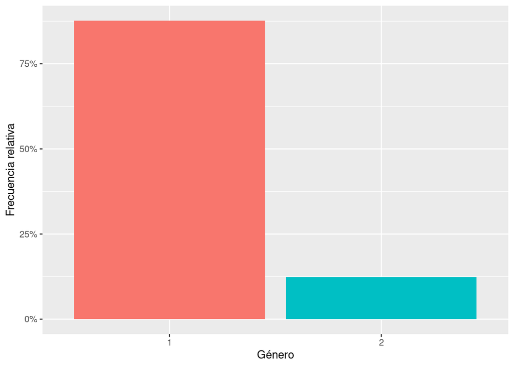

```r
# Representamos un diagrama de barras.
ggplot(data = train_Data, aes(x = gender, fill = gender)) +
  geom_bar(aes(y = (..count..)/sum(..count..))) +
  scale_y_continuous(labels = scales::percent) +
  theme(legend.position = "none") +
  ylab("Frecuencia relativa") +
  xlab("Género")
```

## NDays.

```r
# Resumen de la variable NDays en train_Data.
summary(train_Data$NDays)
```

```
##    Min. 1st Qu.  Median    Mean 3rd Qu.    Max.
##     2.0   850.5  1939.0  2017.2  3137.5  5349.0
```

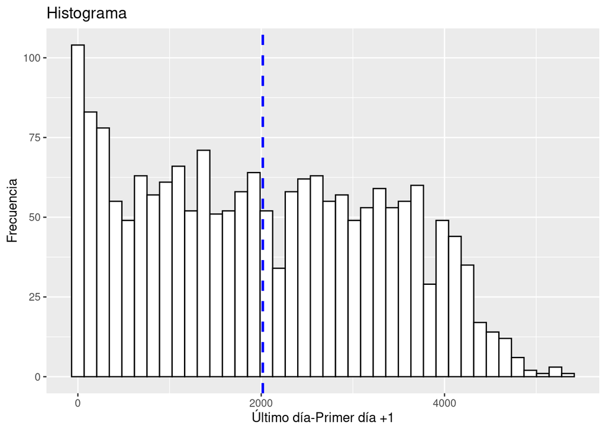

```r
# Veamos la forma de su distribución con un histograma. La línea azul representa la media.
NDays_hist<-histogram(NDays, x_label= "Último día-Primer día +1"); NDays_hist
```

*Los datos no provienen de una distribución normal.*

```r
# Veamos su función de densidad de probabilidad.
NDays_pdf<- pdf(NDays, x_label='Último día-Primer día +1'); NDays_pdf
```

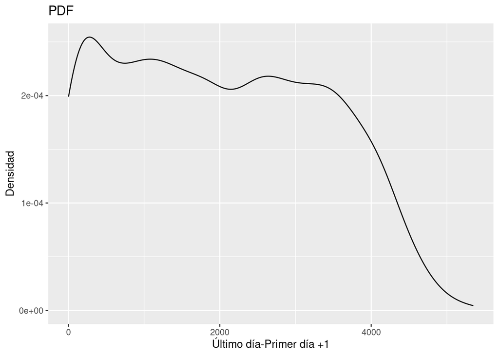

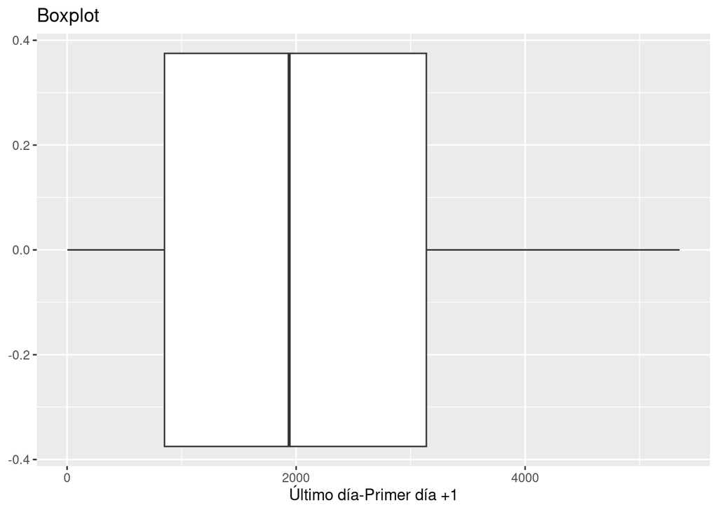

```r
# Boxplot.
bp_NDays<-boxplot(NDays, x_label='Último día-Primer día +1'); bp_NDays
```

*No se observan datos atípicos*.

## NActDays, NPages y NPcreated.

Estudiaremos en conjunto estas variables al presentar una distribución similar. Se obtienen conclusiones similares de todas ellas.

```r
# Resumen de la variable NActDays en train_Data.
summary(train_Data$NActDays)
```

```
##    Min. 1st Qu.  Median    Mean 3rd Qu.    Max.
##     2.0    24.0    51.0   187.5   156.5  3675.0
```

```r
#NActDAys - Estimación unimodal
mlv(train_Data$NActDays, method = "meanshift")
```

```
## [1] 27.07265
## attr(,"iterations")
## [1] 20
```

```r
# Resumen de la variable NPages en train_Data.
summary(train_Data$NPages)
```

```
##    Min. 1st Qu.  Median    Mean 3rd Qu.    Max.
##     1.0    28.0    65.0   801.4   200.0 94142.0
```

*Conclusiones similares a las de la variable NActDays*

```r
# Resumen de la variable NPcreated en train_Data.
summary(train_Data$NPcreated)
```

```
##     Min.  1st Qu.   Median     Mean  3rd Qu.     Max.
##     0.00     1.00     3.00    41.78    14.00 13394.00
```

*En este caso encontramos valores más bajos, aunque, al igual que las otras dos variables, la distribución tendrá una gran asimetría a la derecha al concentrarse los datos en los valores bajos (1Q= 1.0)*

Observemos sus distribuciones.

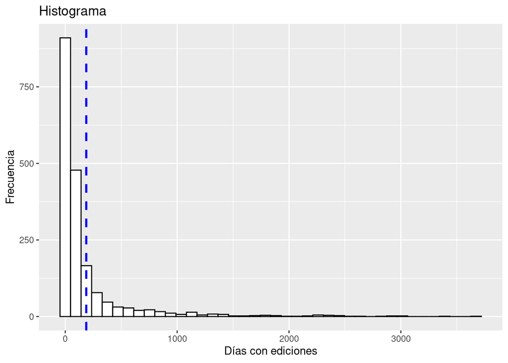

```r
# NActDays - Veamos la forma de su distribución con un histograma
NActDays_hist<-histogram(NActDays, x_label='Días con ediciones'); NActDays_hist
```

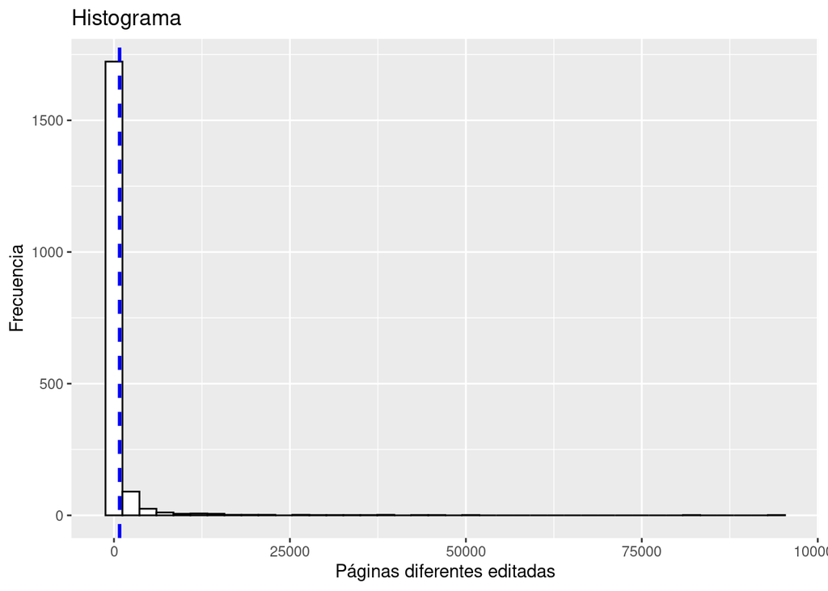

```r
# NPages - Veamos la forma de su distribución con un histograma
NPages_hist<-histogram(NPages, x_label='Páginas diferentes editadas'); NPages_hist
```

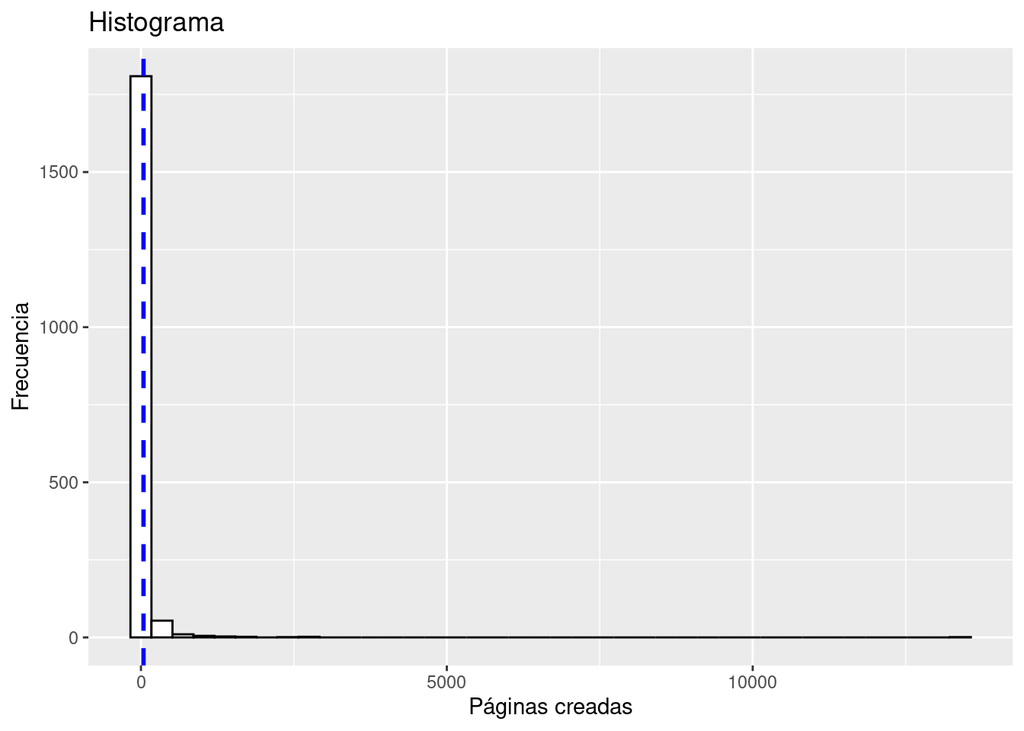

```r
# NPcreated - Veamos la forma de su distribución con un histograma
NPcreated_hist<-histogram(NPcreated, x_label='Páginas creadas'); NPcreated_hist
```

*Como se puede observar, todas las distribuciones presentan baja uniformidad y una notable asimetría a la derecha.*

```r
# NActDays - Veamos su función de densidad de probabilidad.
NActDays_pdf<- pdf(NActDays, x_label='Días con ediciones'); NActDays_pdf
```

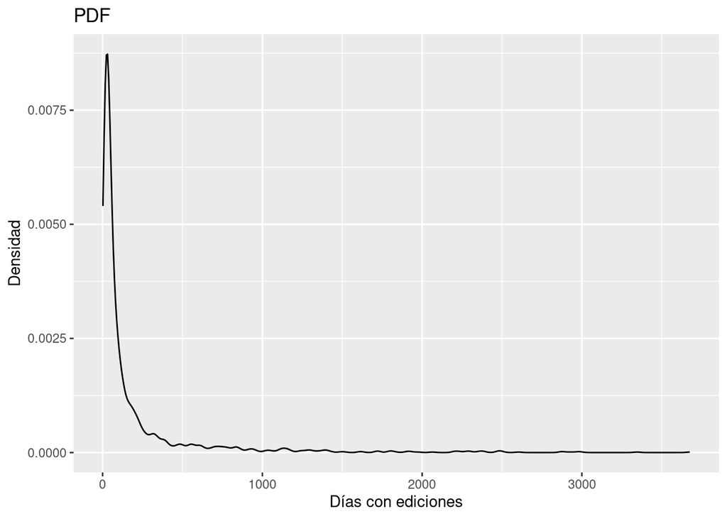

```r
# NPages - Veamos su función de densidad de probabilidad.
NPages_pdf<-pdf(NPages, x_label='Páginas diferentes editadas'); NPages_pdf
```

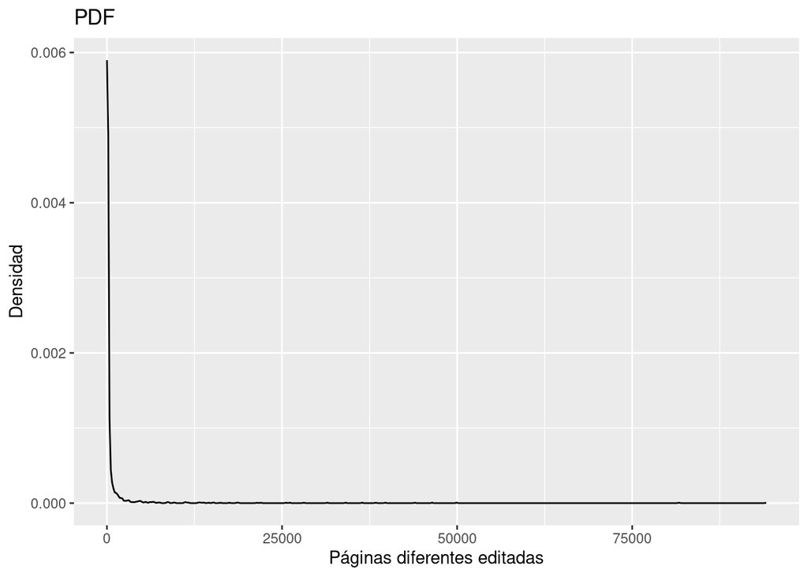

```r
# NPcreated - Veamos su función de densidad de probabilidad.
NPcreated_pdf<-pdf(NPcreated, x_label='Páginas creadas'); NPcreated_pdf
```

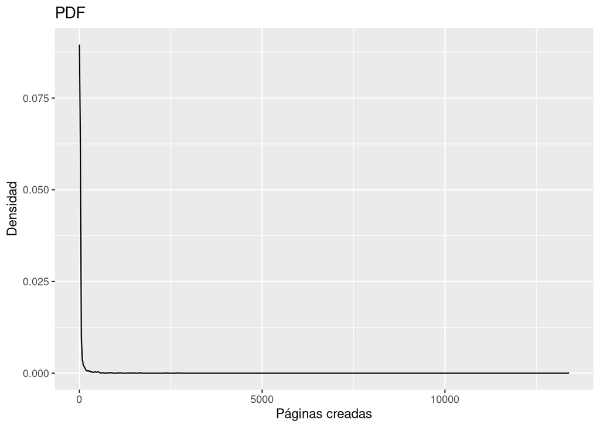

*La probabilidad siempre se encuentra concentrada en los valores bajos. Esto es esperado, considerando los datos analizados anteriormente.*

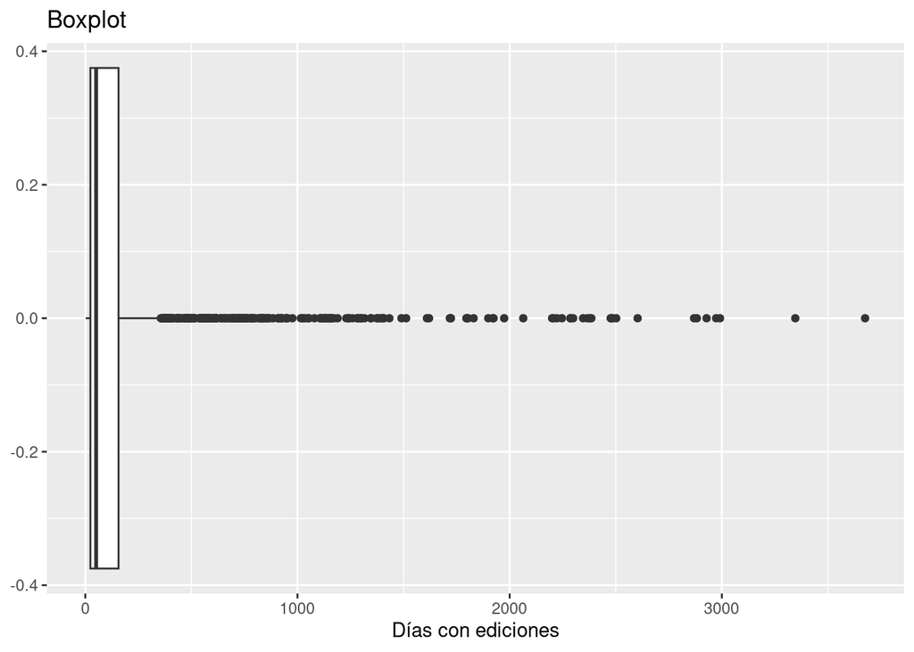

```r
# NActDays - Diagrama de caja.
bp_NActDays<-boxplot(NActDays, x_label='Días con ediciones'); bp_NActDays
```

*Observamos muchos datos superiores a Q3 + 1.5RI. Sin embargo, solo se considerarían datos atípicos aquellos con valor superior a 3000 aproximadamente.*

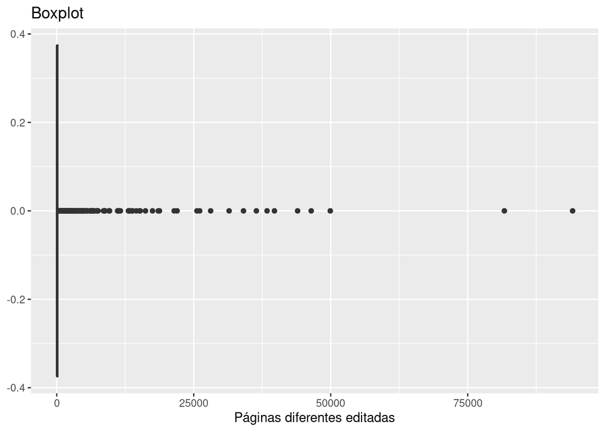

```r
# NPages - Diagrama de caja.
bp_NPages<-boxplot(NPages, x_label='Páginas diferentes editadas'); bp_NPages
```

*Observamos muchos datos superiores a Q3 + 1.5RI. Sin embargo, solo se considerarían datos atípicos aquellos con valor superior a 40000 aproximadamente.*

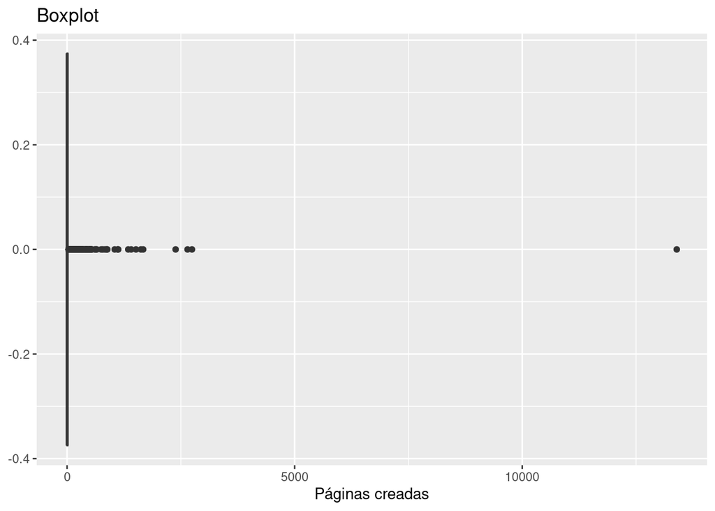

```r
# NPcreated - Diagrama de caja.
bp_NPcreated<-boxplot(NPcreated, x_label='Páginas creadas'); bp_NPcreated
```

*Observamos un par de datos atípicos a partir del valor 2000. Especialmente, cabe destacar el valor máximo de la función, el cual es superior a 6000.*

*Esta variable indica el número de páginas creadas. Puede haber sido dato introducido erróneamente, aunque podría ser verídico, y no parece pertenecer a ninguna de las variables cercanas, i.e NPages o pagesWomen.*

Transformemos los datos para poder trabajar con una distribución con mejores propiedades. **Véase que NPcreated, al ser una variable esparsa, no acepta una transformación box cox.**

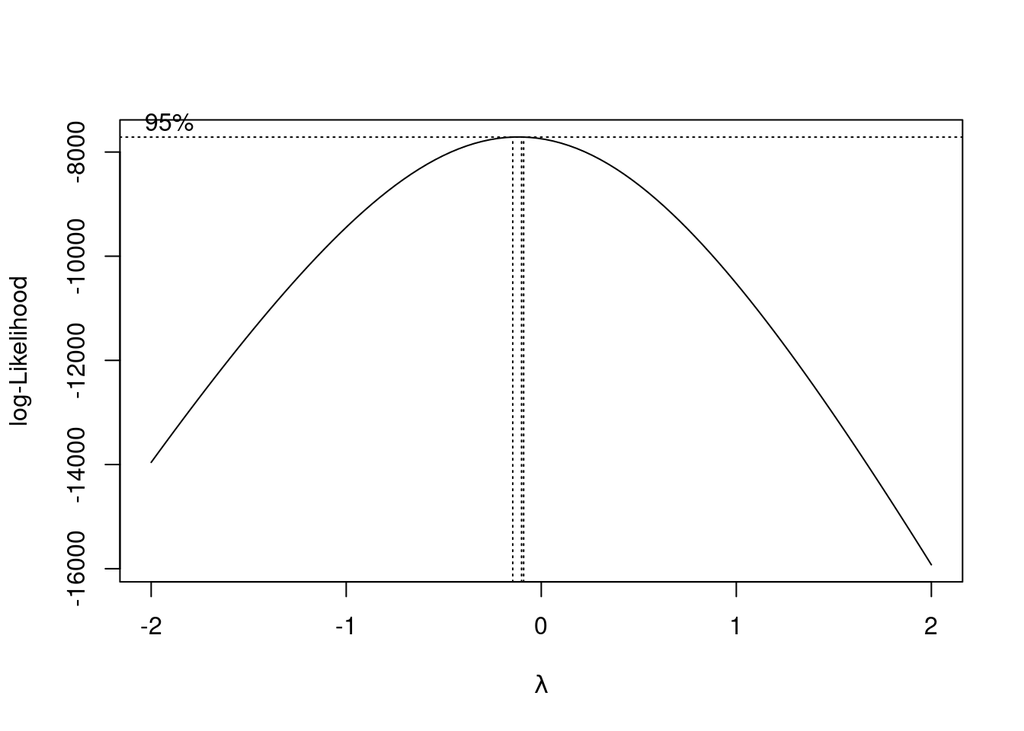

```r
# NActDays - Transformación de datos (box cox).
boxcox(lm(train_Data$NActDays ~ 1))
```

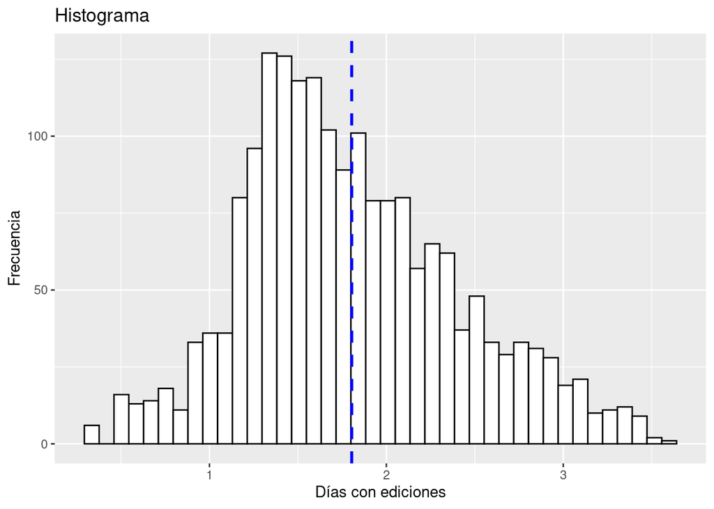

```r
new_NActDays<- log10(train_Data$NActDays)
#Representamos el histograma con los datos transformados
histogram(new_NActDays, x_label='Días con ediciones')
```

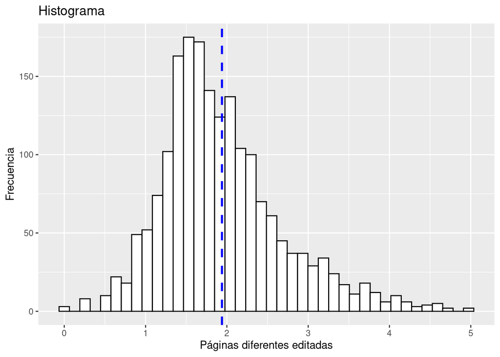

```r
new_NPages<- log10(train_Data$NPages)
#Representamos el histograma con los datos transformados
histogram(new_NPages, x_label='Páginas diferentes editadas')
```

## pagesWomen

```r
# Resumen de la variable pagesWomen en train_Data.
summary(train_Data$pagesWomen)
```

```
##     Min.  1st Qu.   Median     Mean  3rd Qu.     Max.
##   0.0000   0.0000   0.0000   0.4499   0.0000 185.0000
```

*Podemos apreciar que, tanto el primer como el tercer cuartil, tienen un valor de 0. Además, la mediana es 0 y la media está muy cercana a 0.Por tanto, estamos ante una **variable dispersa**, puesto que la mayoría de valores son 0.*

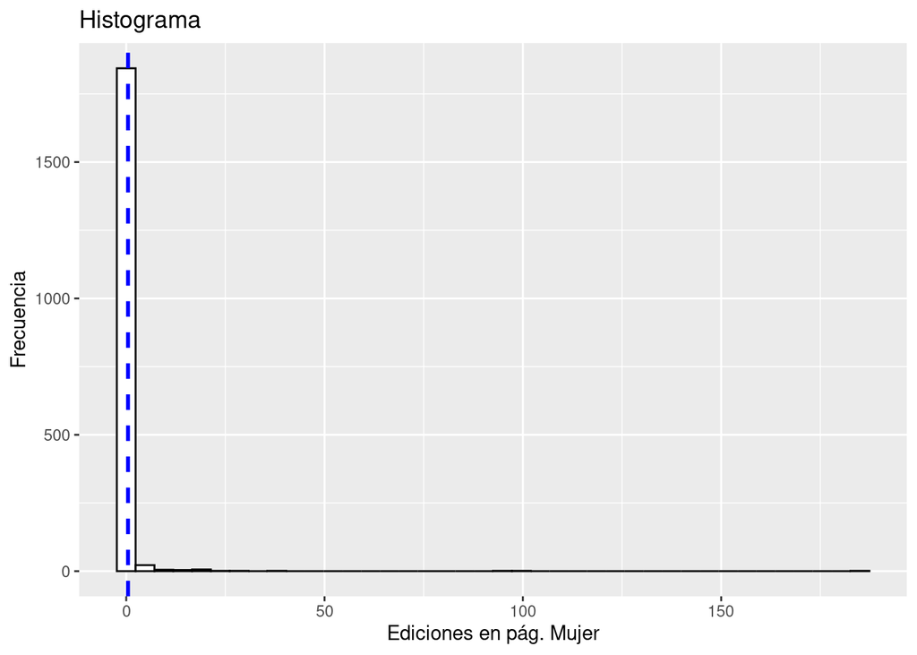

```r
# Veamos la forma de su distribución con un histograma
pagesWomen_hist<-histogram(pagesWomen, x_label='Ediciones en pág. Mujer'); pagesWomen_hist
```

*Confirmamos nuestra conclusión anterior*

```r
# Veamos su función de densidad de probabilidad.
pagesWomen_pdf<-pdf(pagesWomen, x_label='Ediciones en pág. Mujer'); pagesWomen_pdf
```

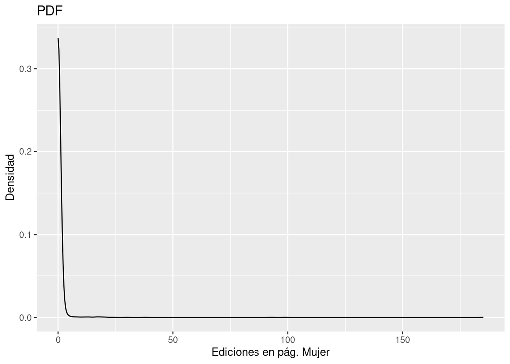

*La probabilidad se encuentra únicamente concentrada en los valores bajos. Esto es esperado, considerando los datos del summary analizado anteriormente.*

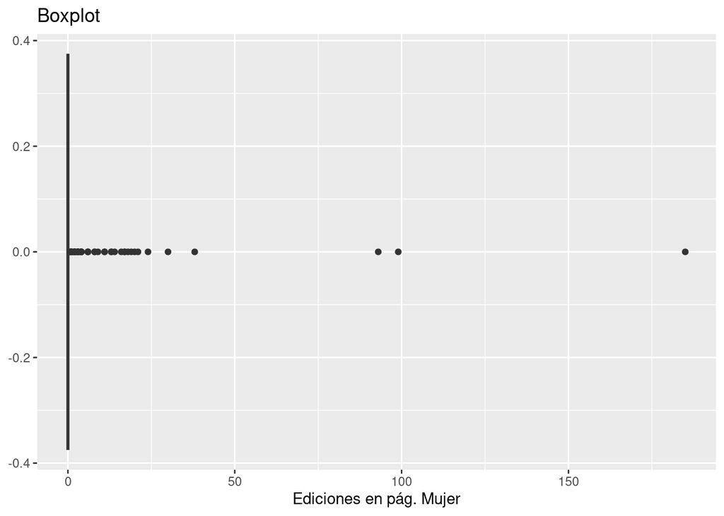

```r
# Diagrama de caja.
bp_pagesWomen<-boxplot(pagesWomen, x_label='Ediciones en pág. Mujer'); bp_pagesWomen
```

## firstDay

Hemos dividido esta variable en 3 datos, siendo estos el primer año de edicion, el primer mes y el primer día.

```r
#Separamos las fechas de los datos
ano_inicial<-as.numeric(substr(train_Data$firstDay,start = 1, stop = 4 ))
#Resumen de la variable
summary(ano_inicial)
```

```
##    Min. 1st Qu.  Median    Mean 3rd Qu.    Max.
##    2002    2007    2010    2010    2013    2017
```

*La media coincide con la mediana por lo que se trata de una variable simétrica, y el primer y tercer cuartil presentan valores típicos.*

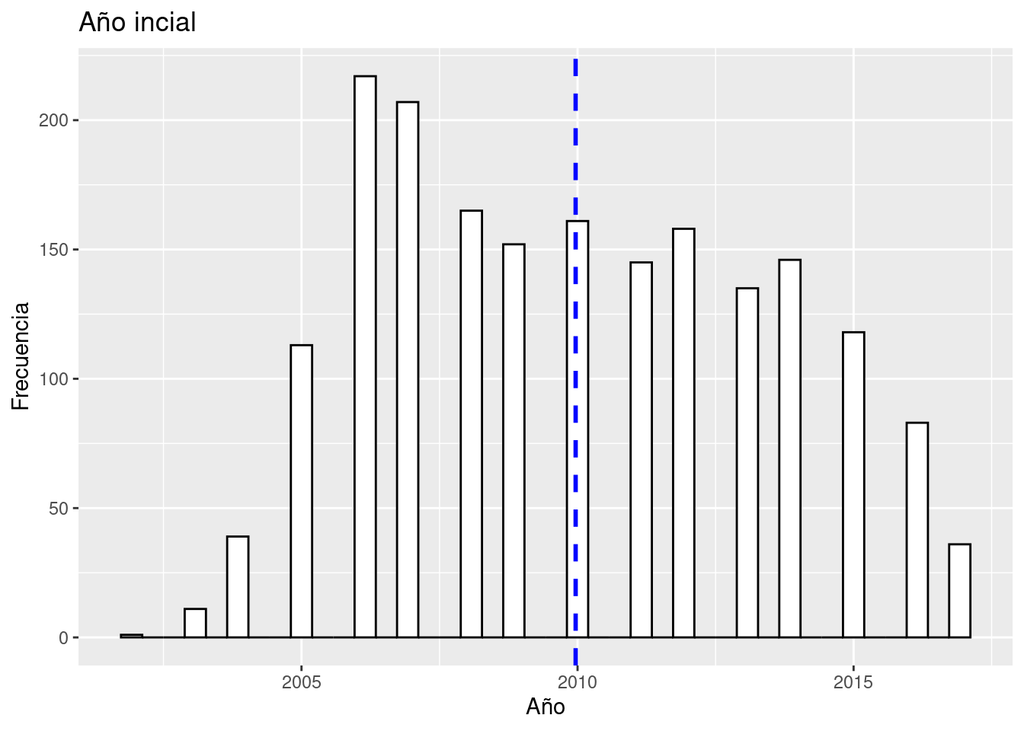

```r
#Vemos su distribucion con un histograma
histogram(ano_inicial,title = "Año incial",x_label = "Año")
```

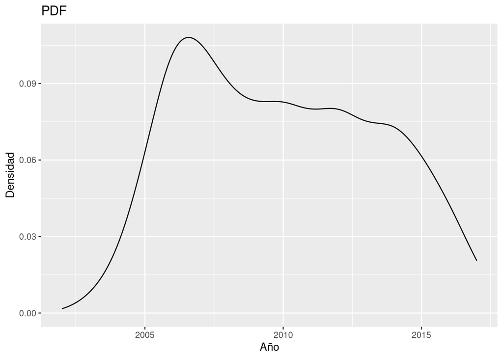

```r
#Año inicial - PDF
pdf(ano_inicial, x_label="Año")
```

*No se consiguen distinguir dos poblaciones.*

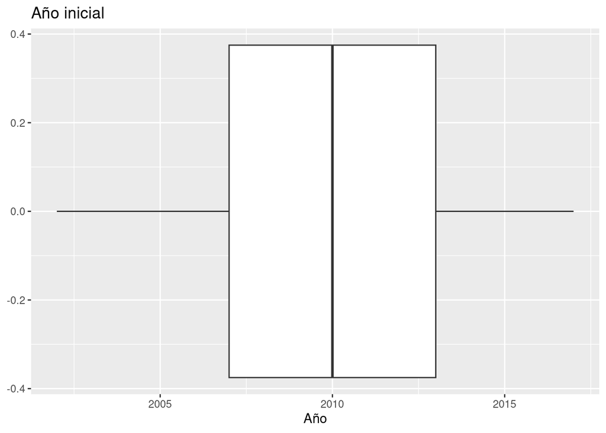

```r
#Año incial - Boxplot
boxplot(ano_inicial,title = "Año inicial", x_label = "Año")
```

*No se observan datos atípicos.* *El año incial puede ser de interés, ya que como veremos ahora, el mes y el día no presentan nada destacable.*

```r
#Obtenemos el mes del dato.
mes_inicial<-as.numeric(substr(train_Data$firstDay,start = 5, stop = 6 ))
#Resumen del mes inicial.
summary(mes_inicial)
```

```
##    Min. 1st Qu.  Median    Mean 3rd Qu.    Max.
##   1.000   3.000   7.000   6.475  10.000  12.000
```

*La mediana está muey cerca de la media por lo que se trata de otra variable muy simétrica. Los cuartiles toman valores típicos.*

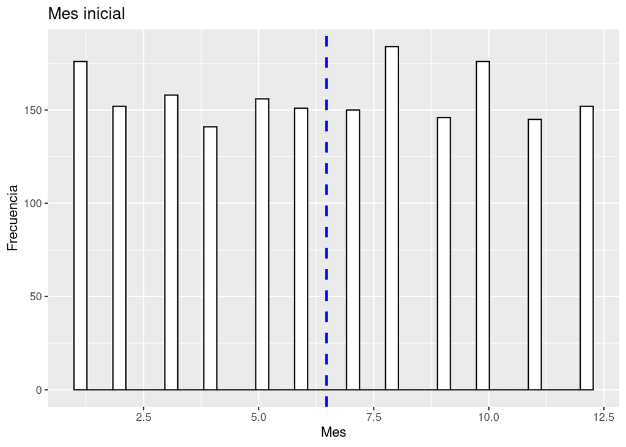

```r
#Mes inicial - Histograma
histogram(mes_inicial, x_label = "Mes",title = "Mes inicial")
```

*El mes de Agosto es en el que mas nuevas cuentas se han creado, no hay nada más destacable*

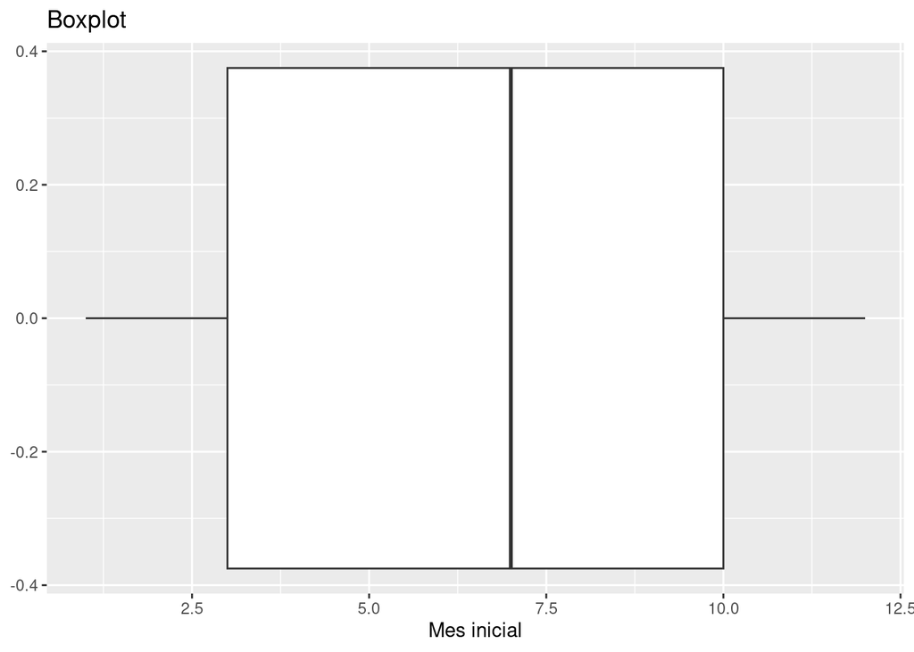

```r
#Boxplot - Mes inicial
boxplot(mes_inicial,x_label = "Mes inicial")
```

*El boxplot no muestra valores atípicos y observamos que en los datos no hay apenas variacion.*

```r
#Obtenemos el día.
dia_inicial<-as.numeric(substr(train_Data$firstDay,start = 7, stop = 8 ))
#Resumen del dato.
summary(dia_inicial)
```

```
##    Min. 1st Qu.  Median    Mean 3rd Qu.    Max.
##    1.00    8.00   16.00   15.79   24.00   31.00
```

*La media y la mediana son parecidas, lo que indica simetría*

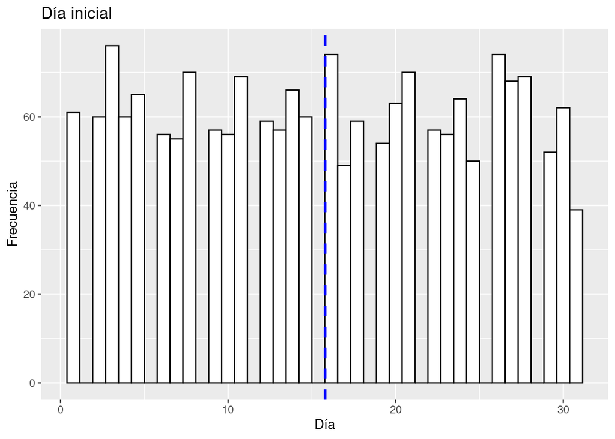

```r
#Dia incial - Histograma
histogram(dia_inicial, x_label = "Día",title = "Día inicial")
```

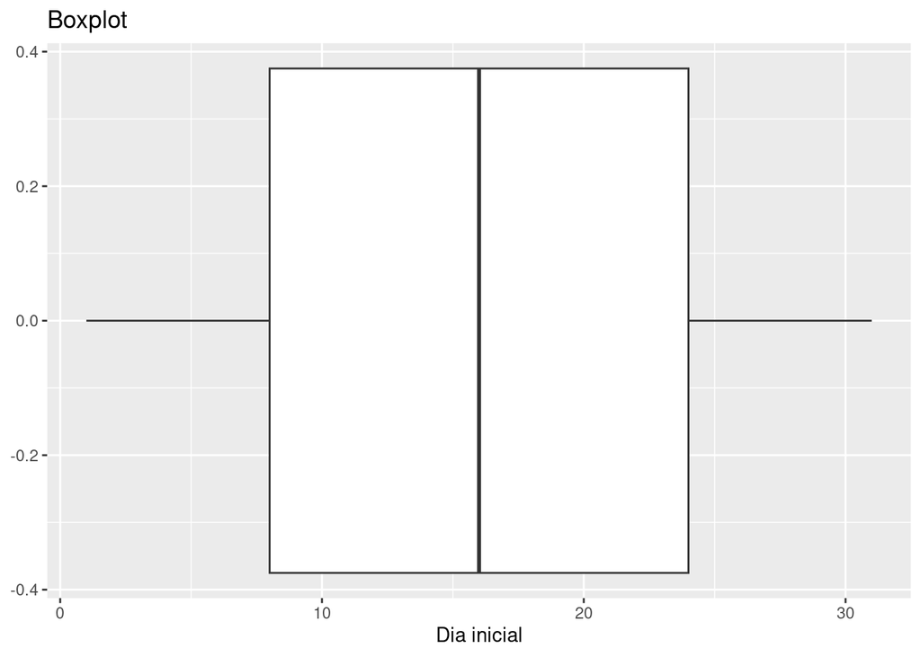

```r
#Día inicial - Boxplot
boxplot(dia_inicial, x_label = "Dia inicial")
```

*Nada destacable.*

**Como hemos podido ver el único dato que parece poder resultar de interés es el año.**

##lastDay Al igual que con firstDay, hemos dividido esta variable en tres datos, siendo estos el año, el mes y el día.

```r
#Obtenemos el año final del dato.
ano_final<-as.numeric(substr(train_Data$lastDay,start = 1, stop = 4 ))
#Resumen del dato.
summary(ano_final)
```

```
##    Min. 1st Qu.  Median    Mean 3rd Qu.    Max.
##    2012    2014    2016    2015    2017    2017
```

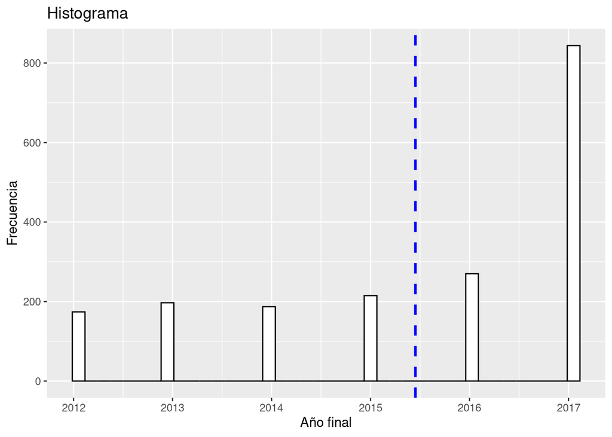

```r
#HAño final - Histograma
histogram(ano_final,x_label = "Año final")
```

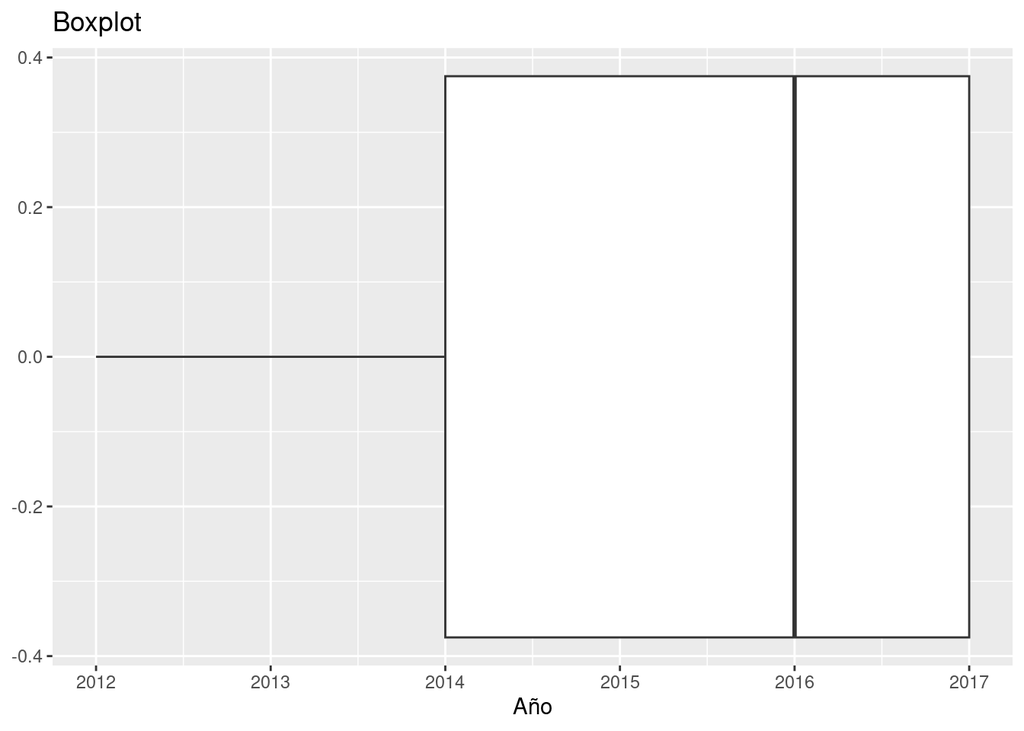

```r
#Año final - Boxplot
boxplot(ano_final, x_label = "Año")
```

*La mayoría de los datos están concentrados en últimos años.*

```r
#Obtenemos el mes final.
mes_final<-as.numeric(substr(train_Data$lastDay,start = 5, stop = 6 ))
#Resumen del dato.
summary(mes_final)
```

```
##    Min. 1st Qu.  Median    Mean 3rd Qu.    Max.
##   1.000   4.000   7.000   6.861   9.000  12.000
```

*Se vuelve a apreciar que los cuartiles son valores estandar, y que la media coincide con la mediana por lo que no se espera nada extraño a la hora de representar los datos.*

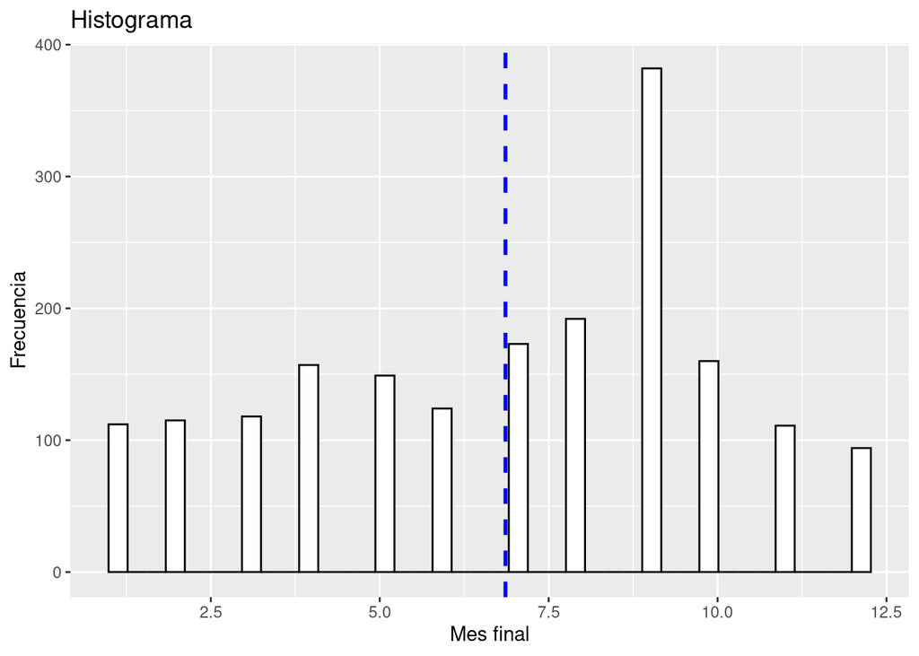

```r
#Mes final - Histograma
histogram(mes_final,x_label = "Mes final")
```

*Pese a la suposicion sacada tras ver el resumen de la variable, hay una gran acumulación de últimas ediciones en el mes de Septiembre, muy notable con respecto al resto.*

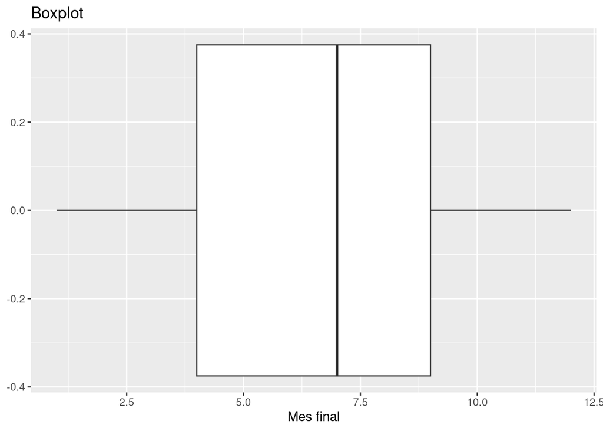

```r
#Mes final - Boxplot
boxplot(mes_final, x_label = "Mes final")
```

*No hay datos atípicos*

```r
#Sacamos el día.
dia_final<-as.numeric(substr(train_Data$lastDay,start = 7, stop = 8 ))
#Resumen del dato
summary(dia_final)
```

```
##    Min. 1st Qu.  Median    Mean 3rd Qu.    Max.
##    1.00    7.50   16.00   15.84   24.00   31.00
```

*Se vuelven a observar valores estandar.*

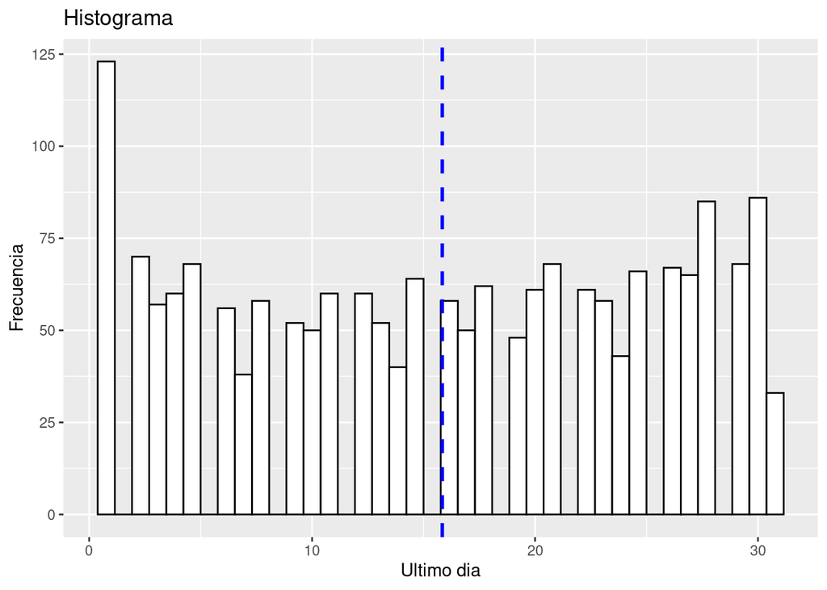

```r
histogram(dia_final, x_label = "Ultimo dia")
```

*Se observa una concentración de últimas ediciones en el primer día del mes. Y que el día con menos cantidad es el 31, lo cual era de esperar, vuelve a ser sorprendete que la diferencia entre el día 31 y el resto de días sea tan pequeña.*

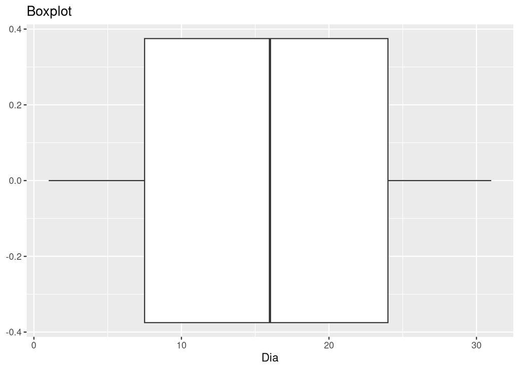

```r
#Dia final - Boxplot
boxplot(dia_final, x_label= "Dia")
```

*No se observan valores atípicos ni nada destacable.*